# Advanced Data Science in Python & R

## Data Cleaning

Since `keras` uses Python data structures, we cannot use the standard `dplyr` methods to clean our dataframe into a form more palatable for input into our `keras` model. Fortunately, the steps in data cleaning for the MNIST dataset are very brief. For our `x` datasets, all we have to do is flatten our two-dimensional arrays of $28\times28$ pixels into $28\times28=784$-dimensional vectors, and then change the units of the grayscale values to vary from $[0,1]$ rather than $[0,255]$ (*the reason for this will be explained later*). For our label vector $y$, we use `to_categorical` to *[one-hot-encode](https://www.quora.com/What-is-one-hot-encoding-and-when-is-it-used-in-data-science)* our labels - this command transforms our scalars $y_i \in [0,9]$ into binary class vectors $y'_i$.

```r
training_set_x %<>% array_reshape(dim = c(nrow(training_set_x), 784)) %>% divide_by(255)
test_set_x %<>% array_reshape(dim = c(nrow(test_set_x), 784)) %>% divide_by(255)
str(training_set_x)
```

```
##  num [1:60000, 1:784] 0 0 0 0 0 0 0 0 0 0 ...
```

```r
training_set_y %<>% to_categorical(num_classes = 10)
test_set_y %<>% to_categorical(num_classes = 10)
str(training_set_y)
```

```
##  num [1:60000, 1:10] 0 1 0 0 0 0 0 0 0 0 ...
```

Now that our data is in the proper matrix format, we’re now all set to craft a `keras` deep learning model to recognize handwritten digits! But first, let’s cover some of the conceptual elements behind deep learning.

# Concepts in Deep Learning

Now that you’ve gotten a sense for the MNIST dataset, let’s learn how to actually tackle this classification problem.

## Handwritten Digit Recognition

#### Check for Understanding

> 1. Why is our model’s accuracy with the training set an insufficient metric to judge our model by? What are the implications of not evaluating your model on the test set - which is separate from the data it was trained on?

Even if you were able to make a successful ruleset to classify this particular image of a $5$, not all $5$’s are alike. Especially for numbers like $7$, which may have a cross-through them or not, or $2$, which may have a looped tail or not, the rules quickly spiral out of reasonable specificity as we try to include more and more special cases to characterize how humans draw numeric digits.

In the past, difficult problems like image classification were met by *domain experts* who persisted through the difficulty of making these rulesets to **preprocess** data like ours into a form more interpretable by computers. Although it can be time-consuming, this process of manual **feature engineering** still remains a major component of data processing today.

To give you an idea of what feature engineering is like, let’s take our example of image classification. [In the $1950$s, two researchers recorded the neural responses of a cat as its retinas were stimulated by slides of large black dots.](https://www.youtube.com/watch?v=IOHayh06LJ4) The objective of the experiment was to ascertain how the cat’s brain was stimulated by the black dots. However, the researchers soon realized that it was actually the black *edges* of the slides that stimulated the cat’s brain most, suggesting that our visual perception relies on **feature detection** - the filtering of an image into lines (like the edge of a slide) and simple shapes to help make sense of visual input. Humans first implicitly perceive images in terms of lines and shapes, before we cast them into more complex textures and patterns. Armed with this knowledge of human perception, we may collaborate with a linguist experienced in how humans write and perceive numbers to transform our dataset of images into a dataset of numerical **features** better suited for a method like regression analysis. For example, we could **feature engineer** our images into vectors with values about where certain lines appear, or indicators of the presence of various shapes, before we attempt to fit a model to them. With some preprocessing, our image classification problem might be more tractable. However, as our previous rule search proved, this task is quite difficult, and very complex problems resist manual feature engineering by humans.

> 3. What are some examples of visual features our eyes might detect in images of numbers?
> 4. Take a few minutes with a partner to fit your three rules into some sort of numeric representation (hint: a 3-dimensional vector of indicators or numeric encodings of features)

Instead of relying on manual feature engineering, we could take inspiration from how humans perceive visual input to construct our model. The initial input to the sensory neurons in our eyes is simply an array of varying light intensities - just like the initial representation of our images! - but we learn to detect features of simple and complex shapes before making sense of the image itself. For example, we may notice two circles stacked upon each other, and subsequently recognize the image as an $8$. Or, we may notice a collection of straight perpendicular lines ending in a half-circle, and recognize the image as a $5$. In our brains, the complex problem of image classification is solved by processing the data in layers, going from raw inputs to features that begin to summarize the information in the data until we finally arrive at **recognition**.

Similarily, in deep learning, we aim to design a model that, rather than requiring preprocessing of its input, learns how to *engineer its own features* out of the raw inputs. Our model would begin with the large vector of raw grayscale intensities, and process the data in **layers**, summarizing the data in stages to ultimately arrive at recognition. Although our model would start without any awareness about our training data, by incrementally feeding all of our training data into a model, our model would slowly learn the characteristics of each category. Taking note of the problem at hand, we must also ensure our model is complex enough to capture all the nuances of the data and its labels - it is this model complexity that earns deep learning the word “*deep*” in its title.

We must also make sure that our dataset is large and well-labeled - with enough representative examples, the performance of neural nets is statistically guaranteed to arbitrarily approximate any supervised task. In this day and age, we have the computational power and large $n$ required to effectively train complex deep learning models to solve problems like handwritten digit recognition.

In the next few sections, you will learn about neural nets in more mathematical detail, but the mathematic structure of neural nets follows the intuition of incrementally transforming raw inputs into more and more descriptive features about the data.

## Neural Nets

### Why Neural Networks now?

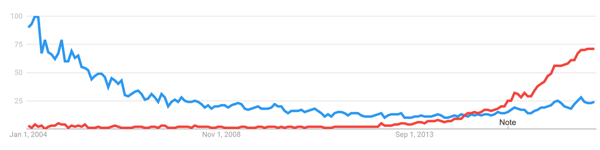

Google Trends Neural Network vs Deep Learning

Above is a graph of google trends for neural networks and deep learning. Can you guess which color is which? Interestingly, neural networks are the blue line, and red is deep learning! Neural networks have been around for a while, and they have only recently become more popular due to new advances.

There are three main differences in machine learning now compared to $30$ years ago.

1. More Data
2. GPUs (more computing power)
3. Better Algorithms

With time, we have been getting more and more data in all areas. The internet provides more images, text, audio than ever before. Now the issue is that we have more data than we know how to deal with. These huge datasets allow us to train deeper models. With GPUs and more computing power, we have the ability to process more data and manage previously infeasible models. We can now train those deeper models. With better algorithms, our models are more efficient and effective.

Interestingly, many people agree that the second difference is the most crucial to our recent developments in machine learning. We are now capable of parsing through gigabytes, terabytes, even petabytes of data for training models hundreds of layers deep. This simply was not possible $30$ years ago. Recent improvements in GPUs has allowed models to train and perform computations in parallel, greatly speeding up the training process.

### What are Neural Networks?

Neural networks derive their name from the neural network we have in our head, our brain. In a highly simplified model, our brain is a collection of **neurons** that receive electrical input signals from **dendrites**, output electrical signals via a single **axon**. Each neuron sends signals along a single axon and connects with other dendrites. Neural networks attempt to model this by having artificial layers neurons that perform minor tasks, then communicate from layer to layer. The collection of neurons operate together to begin to understand the raw input in layers - in each layer, the neurons summarize the data a little bit further, until they finally arrive at a single label.

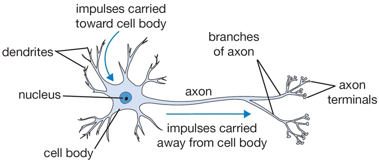

Above is an image of the neurons and axons.

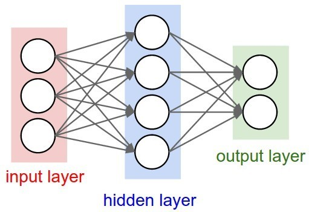

In the diagram of a neural net shown above, the circles represent nodes, or neurons, and the arrows represent the communication between nodes. These nodes are **feed forward** since the information propagates from the input on the left side through intermediate calculations to a final output layer. Our goal in machine learning is to take a set of inputs $X$ and approximate some function $f^*(X)$. We are given $(X_i,y_i)$ pairs where $y\approx f^*(x)$ is an approximation of the example relationships between $X_i$’s and $y_i$’s. These feed-forward models attempt to model $f^*(x)$ by composing multiple functions together, such as $f^*(x)=f^{(2)}(f^{(1)}(x))$ in the neural network above. Notice that $f^{(1)}(x)$ is the middle layer in the model, but it is never used except in intermediate states, thus it is known as a **hidden layer**.

The beauty of neural networks is that they automatically determine the values of these intermediate functions and chain them together to approximate the function without any *a priori* knowledge. In neural networks of images, the early layers work with simple shapes like colors and edges and work towards more complex textures, patterns, and finally to recognition of full objects. Breaking down our model into stages, or layers, takes advantage of the numerous hidden layers to create complex features from combinations of simple ones. By the end of the last layer, the raw inputs are finally condensed into one of the labels of our data - thus acheiving recognition.

### How do Neural Networks work?

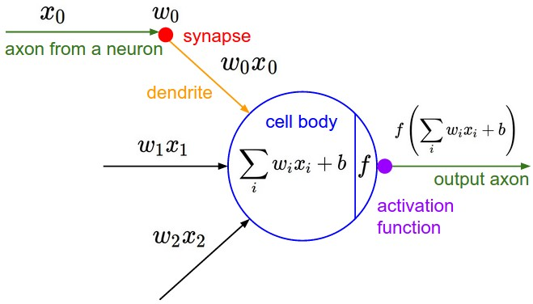

Images from CS231n Stanford.

Above is an image of a zoomed in an individual neuron. In this case, we have a single neuron, with multiple inputs. The general idea is to take all the inputs to the neuron from various dendrites, sum them, and perform some function on the sum. We also have a certain weight to each dendrite, so it is a linear combination of the inputs. There are many valid possible functions to perform at the end, known as *activation functions*. We will go into these in the next section.

To delve more into the math, each neuron outputs a specific value, denoted as $x_i$. This neuron then has separate weights for each further neuron it connects to and multiplies each weight to $x_i$ to serve as the input to a new neuron deeper in the model. In the image above, we have three inputs $x_0,x_1,x_2$ from three neurons. Each individual arrow from neuron to neuron has a unique weight, and each weight gets multiplied by the output axon value from the neuron. To determine the output of the blue neuron, we take the sum of the $x_iw_i$, then apply some activation function $f$. This gives us $f\left(\sum_i w_ix_i + b\right)$. The added $b$ term is not too important, essentially we also include a bias term, a constant value we add.

#### Check for Understanding

> 1. How many weights are in the three-layer neural network image above (not counting biases)?
> 2. What happens if we use a linear activation (such as $ax+b$)?

## An Introduction to Activation Functions

To answer the second question above, consider each activation function in the neural network to be linear of the form$f^{(i)}(x)=a_ix+b_i$. Then if we compose many of these linear functions together, we would get some $f(x)=f^{(n)}(f^{(n-1)}(\ldots f^{(1)}(x)\ldots ))=ax+b$ for some $a,b$. Since the composition of multiple linear functions is always a linear function, we essentially will conduct linear regression. Without the inducement of nonlinearities, our model can only do as well as linear regression. So what activation functions can we use instead of linear functions?

There are many common activation functions.

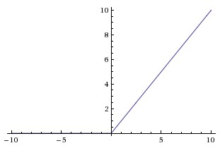

Rectified Linear Units (ReLU) $\max(0,x)$

Rectified Linear Units (ReLU) is one of the most common activation functions used. It is simply the function $\max(0,x)$, essentially thresholding at zero.

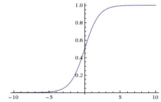

Sigmoid $1/(1+e^{-x})$

Sigmoid is also very commonly used as an activation function. It has the unique property of approaching $0$ as $x$ approaches $-\infty$, approaching $1$ as $x$ approaches $\infty$, and $1/2$ at $0$. This gives an inherent probability mapping from $(-\infty,infty)$, where the larger the value of $x$ the higher the probability.

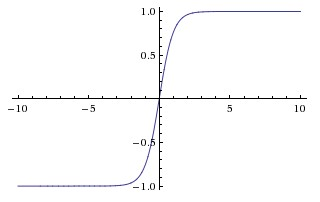

Hyperbolic Tangent ($\textit{tanh}$)

$\textit{tanh}$ has many advantages over sigmoid since the activation function is centered at zero, and can output negative numbers. In practice, $\textit{tanh}$ is preferred over sigmoid.

## How Neural Networks Learn

The general idea in machine learning is given a model and dataset, we would like to minimize the loss or error of the model as it compares to the actual labels of the data. In deep learning, this is acheived by tweaking the weights of the neural network as we incrementally train on the train data to predict the misclassified numbers better. This leads us to two major questions: $(1)$ what is the **loss function** of our model, and $(2)$ how do we update the weights of our model as we train it?

### Loss Function for Classification

As a naive attempt at creating a loss function, we could have the loss be $0$ for correctly classifying the number and $1$ for incorrect classification. However, this is a bit naive because we lose a lot of information on what the correct answer is. A better loss function for classification is **cross entropy loss**. The formula may look a bit complex but the idea is simple. For a particular label $y$ and prediction distribution $\hat{y}$, our error is:
$$z(\hat{y}) = -\sum_k y_k \log {\hat {y}}_k$$
where $y_k$ is an indicator of the correct label and $\hat{y}_k$ is our model’s guess at how likely label $k$ is correct.

For example, if the current image is actually a $3$, then $y_3=1$ and $y_i=0$ for all $i\neq 3$. The $\hat y$ represents the probability distribution outputs from our model. Our model may classify the image as $20\%$ likely to be $1$, $30\%$ likely to be $2$, $50\%$ likely to be $3$, and $0%$ for the rest. The error would be the compute to be $z(\hat y) = -\log(0.5)$.

The key thing to notice about the cross-entropy loss is that the loss drastically increases as the probability for the correct label approaches zero. If we output a very low probability for the correct class, the logarithm approaches very large negative values, resulting in a large loss. On the other hand, if we output a very high probability close to $1$ for the correct class, the loss is almost zero since $\log 1 = 0$.

#### Check for Understanding

> 1. Compute the log loss for a $7$ that was predicted to be $\hat y_7 = 90\%$ and $\hat y_1 = 10\%$. How does this match with your intuition for how cross-entropy operates?

### Back Propagation

Back propagation is the key to training neural networks. To explain back propagation, we may begin with an analogy. Consider that today after eating, you get a bad stomach ache and suspect that you got food poisoning. A logical step would be to assign blame to the most recent foods you ate, placing more blame on the more suspect foods such as raw fish, raw meats, etc. We intuitively place the blame on the more recent things, then consider the causes farther back such as the leftover salad you left in the fridge for a week or the spoiled milk from that boba place you knew you shouldn’t have gone to.

Back propagation is similar, we distribute the loss through the model beginning with the layers closer to the output, and propagate the loss back. The exact math is a bit complex as it involves a lot of derivatives, but the general idea is relatively simple. The more suspicious or the more the neuron contributed to the incorrect prediction, the more we penalize it to be correct.

### Recap

To take a moment to recap, a neural network consists of **layers** of nodes. We feed in data to our model, and as it guesses the class of each data point, we penalize it for missclassifications. The worse the missclassification, the higher the penalty, or **loss**. These losses are then used via the back propagation algorithm to tweak the most relevant weights in the network. Over time, our weights will gradually shift to make our model more and more accurate.

Because our weights are designed to only shift a tiny bit at a time, we pass our training set through our model multiple times to get our weights to converge to their most performant values. Each pass is known as an **epoch**, and we generally need many epochs for our model’s weights to converge.

Now that you understand the basics behind how neural nets are constructed and learn from training data, let’s get to actual implementations of neural nets applied to our MNIST image classification problem.

# `Keras` in Python

Please refer to the Python version of the notebook.

# `Keras` in R

First, we declare our `mnist_model` to be the simplest of the deep learning architectures, a forward-feed-only **sequential** network. We then add three layers: $(1)$ a raw **input layer** with 784 nodes, one for each pixel, $(2)$ an intermediary **hidden layer** which feature engineers our raw input into 30 nodes, and finally an **output layer** which gives the 10 likelihoods for $\hat y_i$.

```r
mnist_model <- keras_model_sequential()
mnist_model %>%
  layer_dense(units = 30, activation = 'relu', input_shape = c(784)) %>%
  layer_dense(units = 10, activation = 'softmax')
```

Note that the first hidden layer, we use the `relu` activation function for reasons outlined above, and whereas the output layer uses `softmax` to transform the weights and node values into a probability distribution of the predicted outputs.

We can verify the structure of our model with the `summary` function, just as we did for linear regression models (`lm`’s).

```r
summary(mnist_model)
```

```
## ___________________________________________________________________________
## Layer (type)                     Output Shape                  Param #
## ===========================================================================
## dense_1 (Dense)                  (None, 30)                    23550
## ___________________________________________________________________________
## dense_2 (Dense)                  (None, 10)                    310
## ===========================================================================
## Total params: 23,860
## Trainable params: 23,860
## Non-trainable params: 0
## ___________________________________________________________________________
```

Our “simple” model has $23,860$ parameters - clearly it’s actually quite a complex model compared to linear regression models which tend to have only one parameter per input feature. The addition of the hidden layers complicated our model, but it is our hope that this additional complexity will lead to a more performant model.

Our next step is to `compile` our model by specifying that we will be using a cross-entropy loss function and a stochastic gradient descent algorithm to optimize our weights, with a learning rate of $0.1$.

```r
mnist_model %>% compile(
  loss = 'categorical_crossentropy',
  optimizer = optimizer_sgd(lr = 0.1),
  metrics = c('accuracy')
)
```

```r
mnist_model %>%
  fit(x = training_set_x, y = training_set_y,
      epochs = 10, batch_size = 100, validation_split = 0.2)
```

The final step of our model is to evaluate it on the test set. Remember that a low training loss is *not* the best measure of a model’s performance - we *must* try it on data it was not trained on to verify our model is robust, and didn’t just overfit to the training set.

```r
mnist_model %>% evaluate(x = test_set_x, y = test_set_y)
```

```
## $loss
## [1] 0.1370926
##
## $acc
## [1] 0.9591
```

Neat! Our relatively simple deep learning model has over $95\%$ accuracy on our test set, so we are reasonably confident it will perform well in recognizing digits “in real life”. Just to see what kinds of mistakes our machine-made model made with the MNIST dataset (there is that last $\sim 4\%$ after all!), let’s plot the first ten mistakes made, along with their true label.

```
## [1] "ID:  9 Actual:  5 Predicted:  6"
```

[figure not shown]

```
## [1] "ID:  125 Actual:  7 Predicted:  4"
```

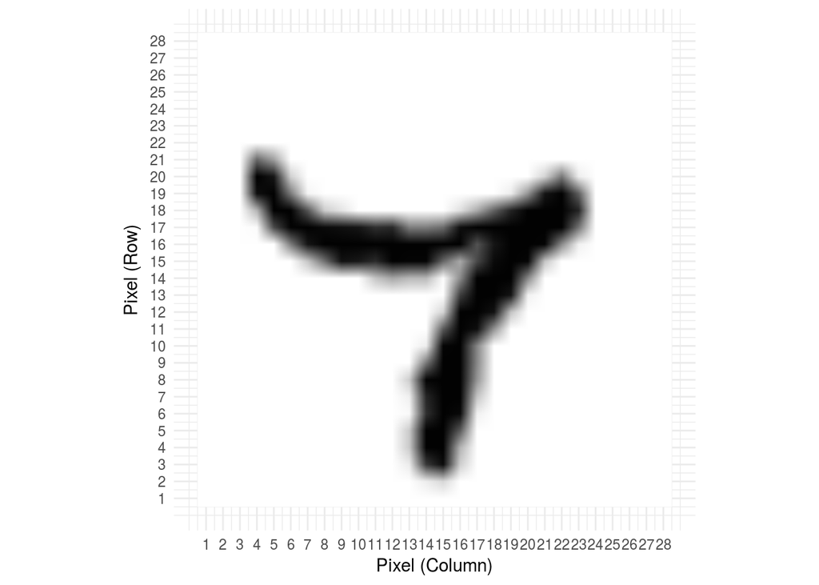

```
## [1] "ID:  150 Actual:  2 Predicted:  9"
```

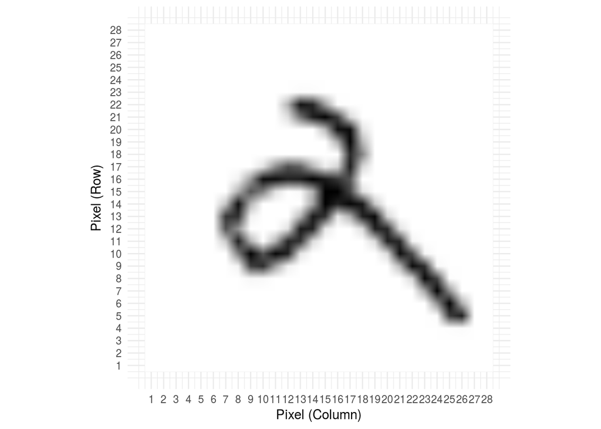

```
## [1] "ID:  242 Actual:  9 Predicted:  3"
```

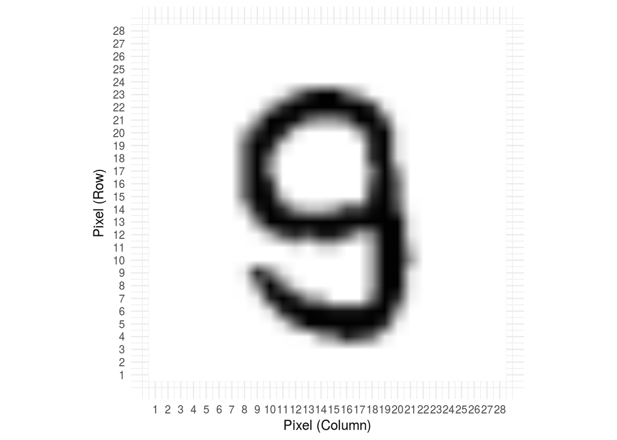

```
## [1] "ID:  248 Actual:  4 Predicted:  2"
```

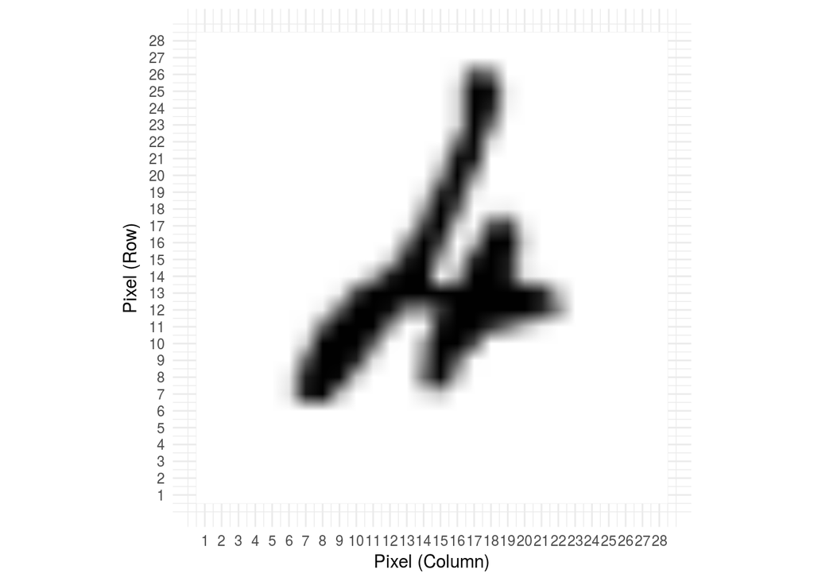

```
## [1] "ID:  260 Actual:  6 Predicted:  0"
```

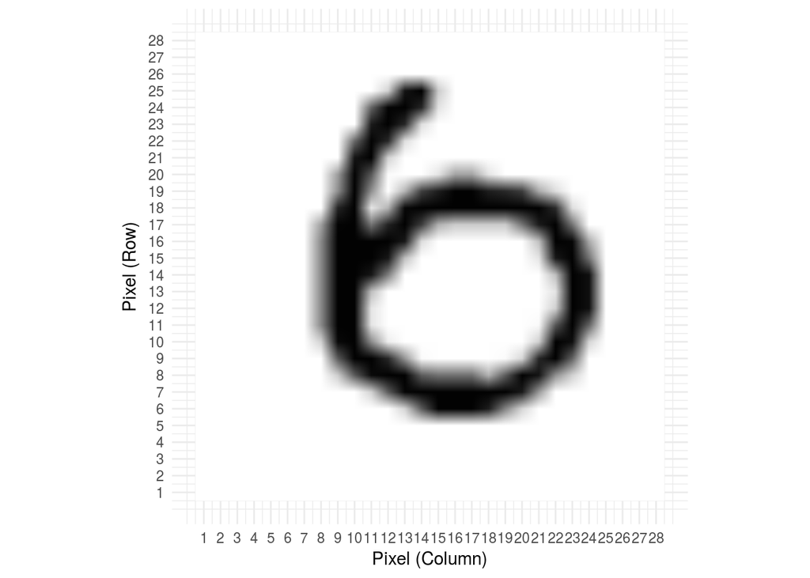

```
## [1] "ID:  301 Actual:  4 Predicted:  6"
```

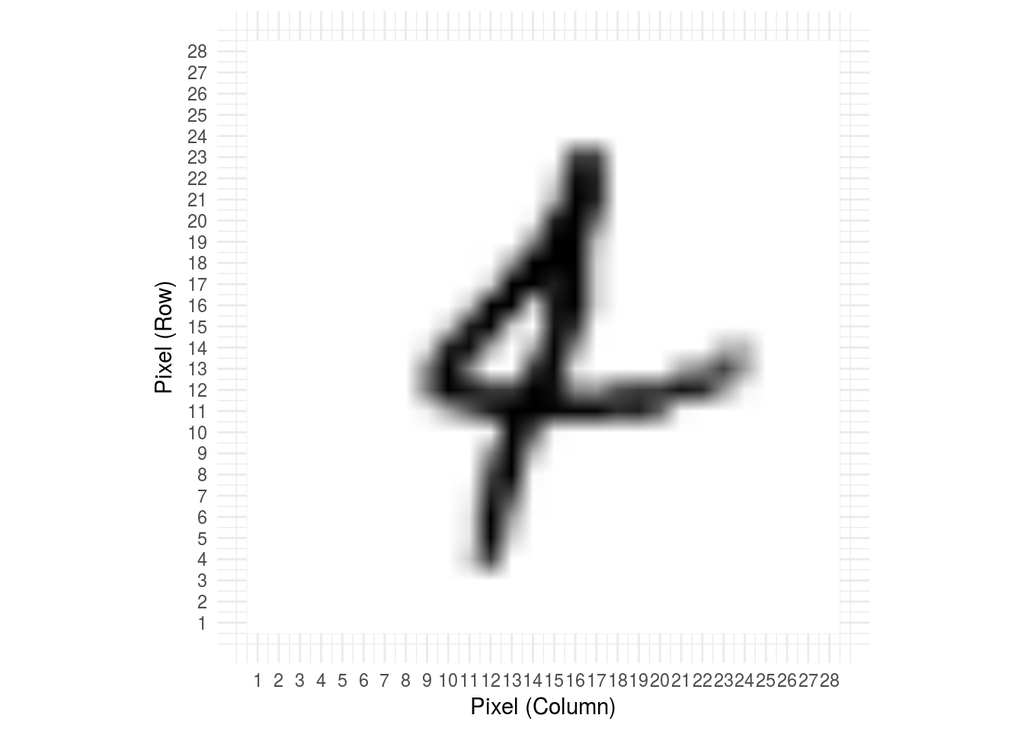

```
## [1] "ID:  321 Actual:  9 Predicted:  7"
```

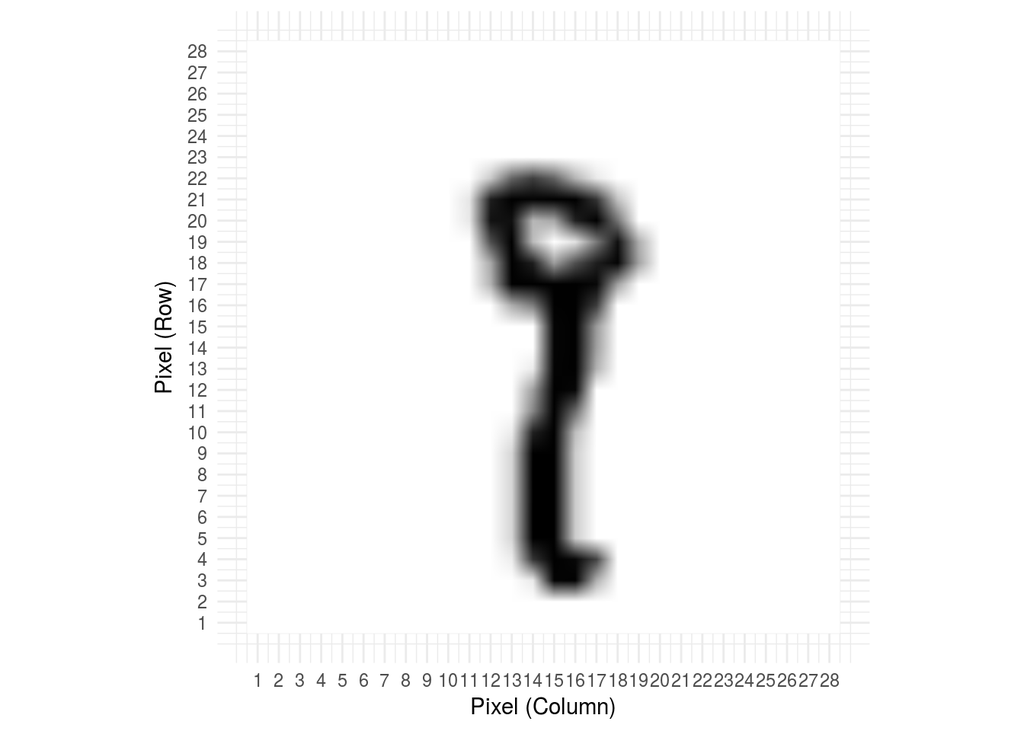

```
## [1] "ID:  322 Actual:  2 Predicted:  7"
```

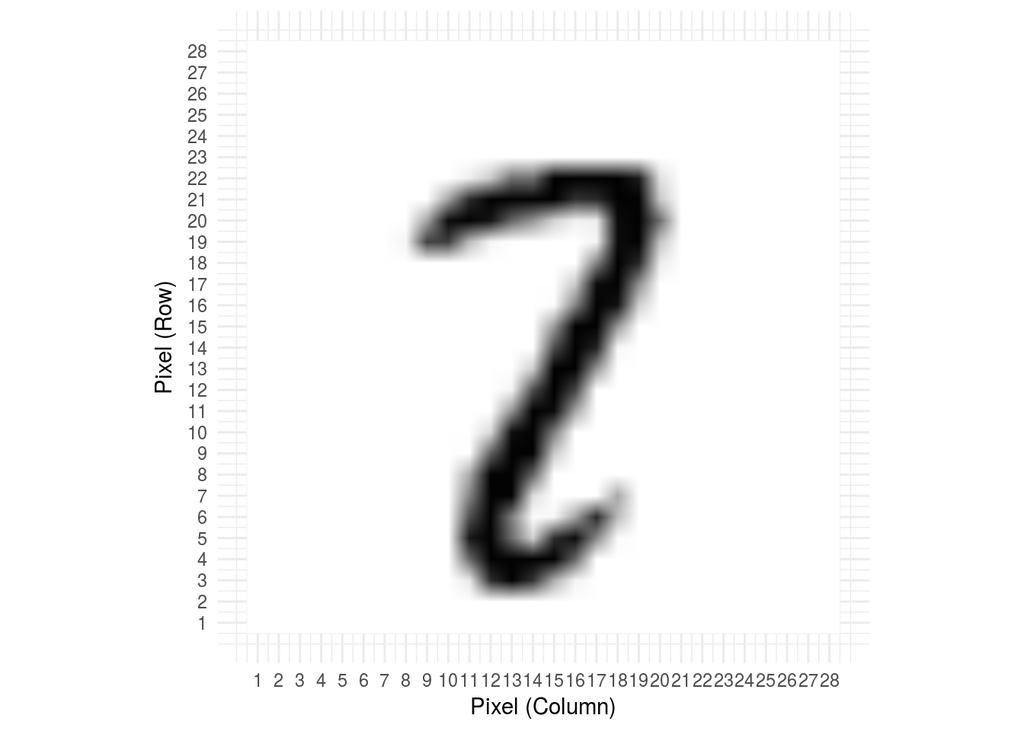

```
## [1] "ID:  341 Actual:  5 Predicted:  3"
```

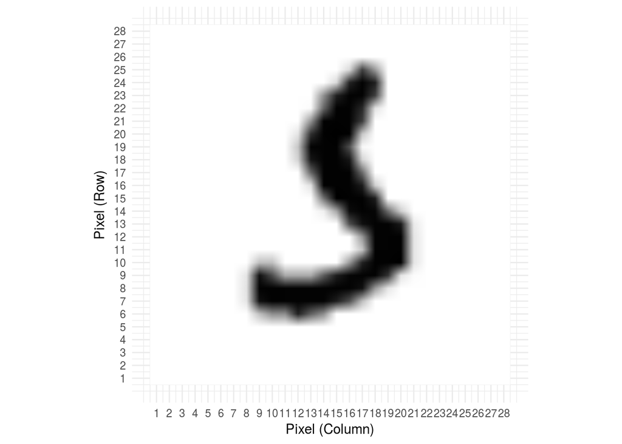

```r
predictions <- mnist_model %>% predict_classes(test_set_x)
incorrect_predictions_ids <- which(predictions != MNIST$test$y) %>% head(10)

verify_prediction <- function(id) {
  print(paste("ID: ", id, "Actual: ", MNIST$test$y[id], "Predicted: ", predictions[id]))
  get_image(id = id) %>% tidy_image %>% plot_image %>% print
}

walk(incorrect_predictions_ids, verify_prediction)
```

#### Check for Understanding

> 1. Discuss the above incorrect outputs with your classmates. Why do you think our model performed badly on these inputs?
> 2. How would you improve our model to better classify inputs like the ones shown here?

# Conclusion

This ends our textbook-style primer into deep learning with Keras. While this was just an introduction to neural nets, we hope that you can now see some of the workflow patterns associated with machine learning. Feel free to play around with the code above to get a better feel for the hyperparameters of the neural net model. As always, please email `contact@arun.run` or `prc@berkeley.edu` with any questions or concerns whatsoever. Happy machine learning!

## Sneakpeek at SUSA Kaggle Competition

After Spring Break, we will be guiding you through a four-week collaborative Kaggle competition with your peers in Career Exploration! We want to give you the experience of working with real data, using real machine learning algorithms, in an educational setting. You will have to choose either Python or R, and dive into reading kernels on the Kaggle website, use visualization and feature engineering to improve your score, and maybe even pick up a few advanced deep learning models along the way. If this sounds a bit intimidating right now, do not fret! Your SUSA Mentors will be there to mentor you through the whole thing. So rest up during Spring Break, and come back ready to tackle your biggest data challenge yet!

# Additional Reading

- This workshop was based on the introductory example for [Keras in R](https://blog.rstudio.com/2017/09/05/keras-for-r/). For more information on the R `keras` package, visit the following websites:
  - The official RStudio website for [Keras](https://keras.rstudio.com) contains a shortened version of the MNIST illustrative example, a textbook reference, and more
  - For a few examples on how to implement sequential neural networks like the one used in this tutorial, visit the [Keras guide to sequential models in R](https://keras.rstudio.com/articles/sequential_model.html)
  - The official [FAQ for Keras in R](https://keras.rstudio.com/articles/faq.html) contains tons of useful information, like the differences between a **sample**, **batch**, and **epoch** as well as useful and easy one-liners to improve or validate your models
- For an interactive guide to learning R and Python, visit [DataCamp](https://www.datacamp.com/) a paid tutorial website for learning data computing.